# MScA, Linear and Non-Linear Models (31010) Week 7: Workshop 1 Gamma Regression

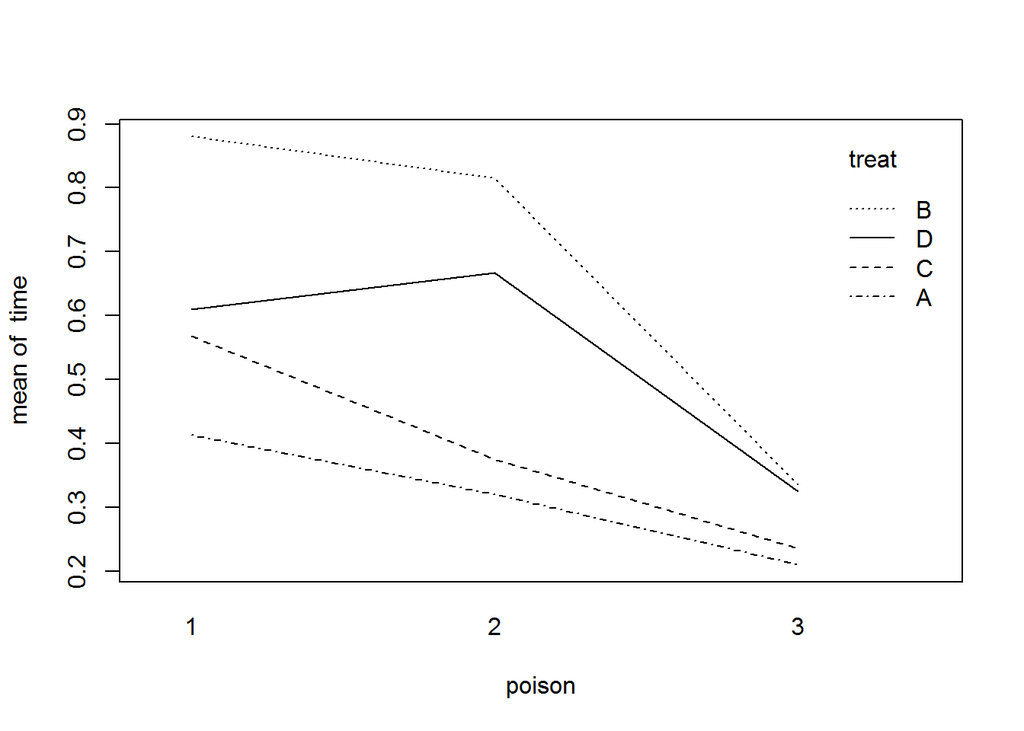

```r
with(poisons,interaction.plot(poison,treat,time))
```

Fit a linear model with main and interaction effects, and name the resulting linear model output object as `mRats`. Then look at the analysis of variance table.

```r
mRats <- lm(time ~ poison*treat,data=poisons)
summary(mRats)
```

```
##
## Call:
## lm(formula = time ~ poison * treat, data = poisons)
##
## Residuals:
##      Min       1Q   Median       3Q      Max
## -0.32500 -0.04875  0.00500  0.04312  0.42500
##
## Coefficients:
##                Estimate Std. Error t value Pr(>|t|)
## (Intercept)     0.41250    0.07457   5.532 2.94e-06 ***
## poison2        -0.09250    0.10546  -0.877   0.3862
## poison3        -0.20250    0.10546  -1.920   0.0628 .
## treatB          0.46750    0.10546   4.433 8.37e-05 ***
## treatC          0.15500    0.10546   1.470   0.1503
## treatD          0.19750    0.10546   1.873   0.0692 .
## poison2:treatB  0.02750    0.14914   0.184   0.8547
## poison3:treatB -0.34250    0.14914  -2.297   0.0276 *
## poison2:treatC -0.10000    0.14914  -0.671   0.5068
## poison3:treatC -0.13000    0.14914  -0.872   0.3892
## poison2:treatD  0.15000    0.14914   1.006   0.3212
## poison3:treatD -0.08250    0.14914  -0.553   0.5836
## ---
## Signif. codes:  0 '***' 0.001 '**' 0.01 '*' 0.05 '.' 0.1 ' ' 1
##
## Residual standard error: 0.1491 on 36 degrees of freedom
## Multiple R-squared:  0.7335, Adjusted R-squared:  0.6521
## F-statistic:  9.01 on 11 and 36 DF,  p-value: 1.986e-07
```

```r
anova(mRats)
```

```
## Analysis of Variance Table
##
## Response: time
##              Df  Sum Sq Mean Sq F value    Pr(>F)
## poison        2 1.03301 0.51651 23.2217 3.331e-07 ***
## treat         3 0.92121 0.30707 13.8056 3.777e-06 ***
## poison:treat  6 0.25014 0.04169  1.8743    0.1123
## Residuals    36 0.80072 0.02224
## ---
## Signif. codes:  0 '***' 0.001 '**' 0.01 '*' 0.05 '.' 0.1 ' ' 1
```

Examine the distribution of the residuals to see if it looks normally distributed, and then plot the residuals relative to the fitted values to see if the variance tends to be larger where the mean survival time is larger. The normal quantile-quantile plot (qqnorm) should give a straight line if the residuals are normal.

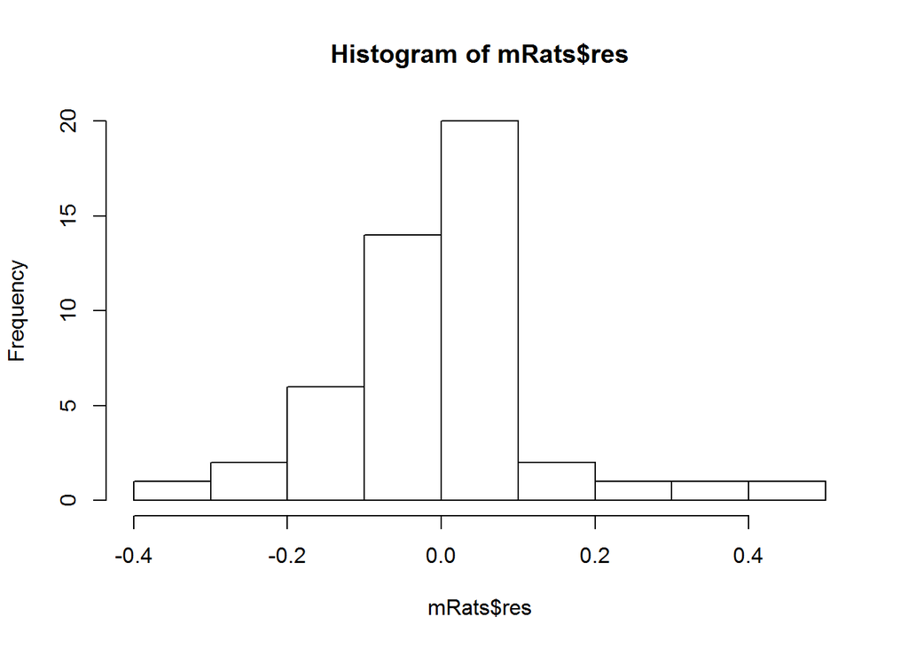

```r
hist(mRats$res)
```

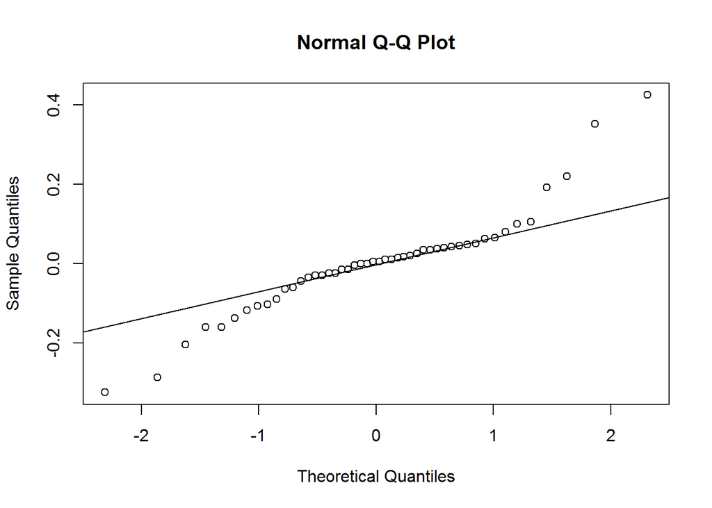

```r
qqnorm(mRats$res)
qqline(mRats$res)
```

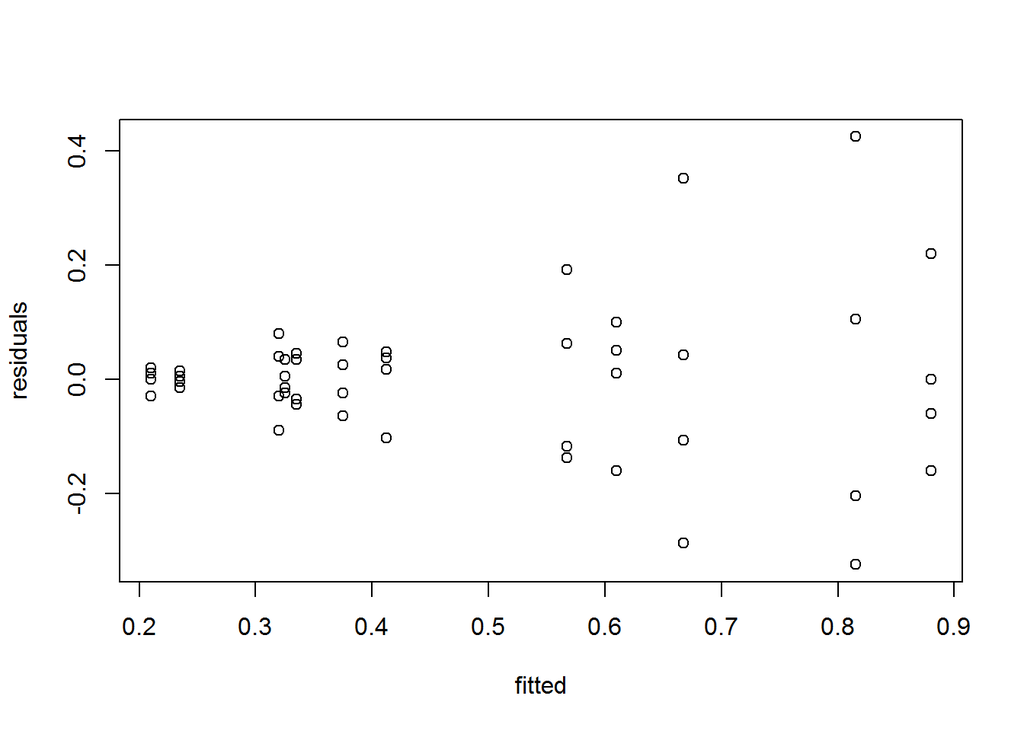

```r
plot(mRats$fitted, mRats$res, xlab="fitted",   ylab="residuals")
```

```r
idx<-(mRats$fitted.values<median(mRats$fitted.values))
bptest(poisons$time~poisons$poison*poisons$treat)
```

```
##
##  studentized Breusch-Pagan test
##
## data:  poisons$time ~ poisons$poison * poisons$treat
## BP = 24.465, df = 11, p-value = 0.01091
```

```r
fligner.test(mRats$residuals,idx)
```

```
##
##  Fligner-Killeen test of homogeneity of variances
##
## data:  mRats$residuals and idx
## Fligner-Killeen:med chi-squared = 14.499, df = 1, p-value =
## 0.0001402
```

Both `bptest()` and Fligner reject the null hypothesis of homoskedasticity. Since the variance indeed does not look constant, try a transformation, taking logarithms of the data.

```r
mRats.log <- lm(log(time) ~ poison*treat,data=poisons)
summary(mRats.log)
```

```
##
## Call:
## lm(formula = log(time) ~ poison * treat, data = poisons)
##
## Residuals:
##      Min       1Q   Median       3Q      Max
## -0.50006 -0.11846  0.01995  0.12202  0.48733
##
## Coefficients:
##                Estimate Std. Error t value Pr(>|t|)
## (Intercept)    -0.89755    0.11626  -7.720 3.82e-09 ***
## poison2        -0.26383    0.16442  -1.605 0.117330
## poison3        -0.66727    0.16442  -4.058 0.000254 ***
## treatB          0.75768    0.16442   4.608 4.94e-05 ***
## treatC          0.30281    0.16442   1.842 0.073777 .
## treatD          0.38891    0.16442   2.365 0.023523 *
## poison2:treatB  0.13472    0.23253   0.579 0.565960
## poison3:treatB -0.29379    0.23253  -1.263 0.214553
## poison2:treatC -0.13101    0.23253  -0.563 0.576659
## poison3:treatC -0.18730    0.23253  -0.805 0.425823
## poison2:treatD  0.30494    0.23253   1.311 0.198023
## poison3:treatD  0.04953    0.23253   0.213 0.832508
## ---
## Signif. codes:  0 '***' 0.001 '**' 0.01 '*' 0.05 '.' 0.1 ' ' 1
##
## Residual standard error: 0.2325 on 36 degrees of freedom
## Multiple R-squared:  0.8252, Adjusted R-squared:  0.7718
## F-statistic: 15.45 on 11 and 36 DF,  p-value: 1.643e-10
```

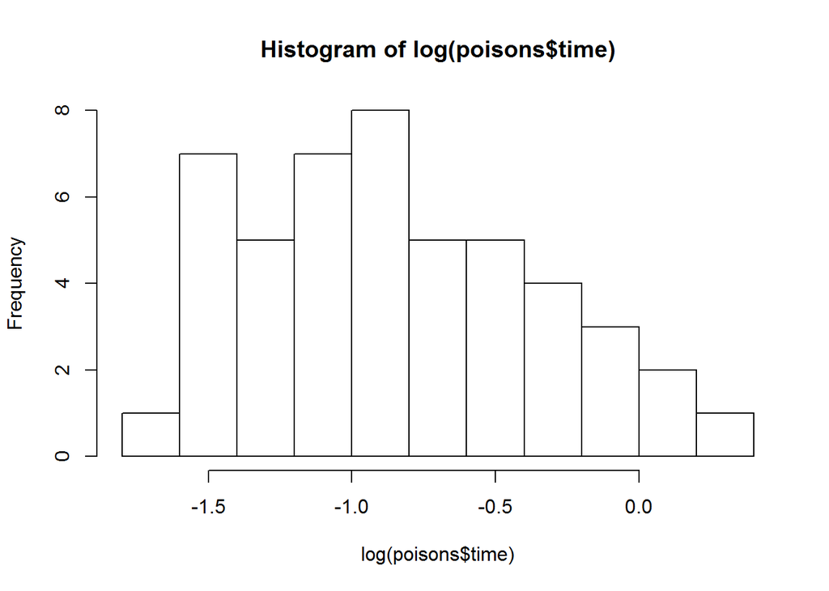

```r
hist(log(poisons$time))
```

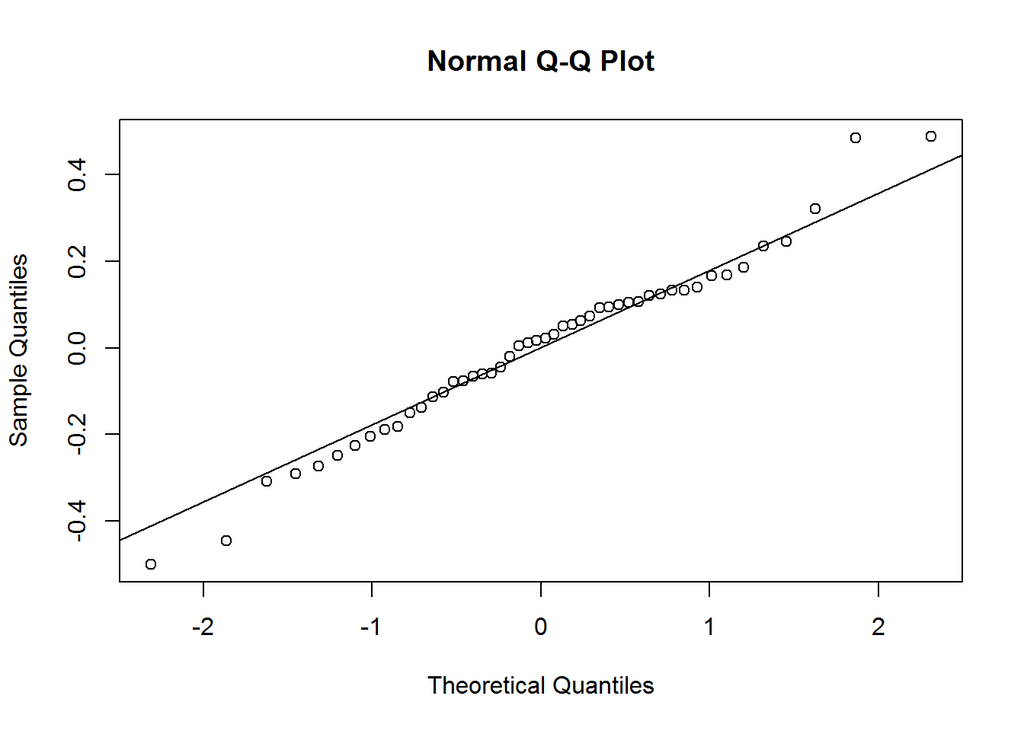

```r
qqnorm(mRats.log$res)
qqline(mRats.log$res)
```

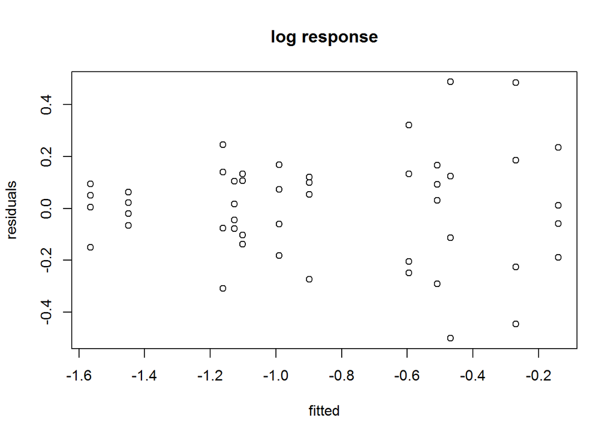

```r
plot(mRats.log$fitted, mRats.log$res, xlab="fitted", ylab="residuals",main="log response")
```

```r
idx<-(mRats.log$fitted.values<median(mRats.log$fitted.values))
bptest(log(poisons$time)~poisons$poison*poisons$treat)
```

```
##
##  studentized Breusch-Pagan test
##
## data:  log(poisons$time) ~ poisons$poison * poisons$treat
## BP = 21.825, df = 11, p-value = 0.02577
```

```r
fligner.test(mRats.log$residuals,idx)
```

```
##
##  Fligner-Killeen test of homogeneity of variances
##
## data:  mRats.log$residuals and idx
## Fligner-Killeen:med chi-squared = 6.8859, df = 1, p-value =
## 0.008688
```

Did not work. Here is one more transformation to try, using the reciprocal of survival time, which could be interpreted as death rate.

```r
mRats.recip <- lm(1/time ~ poison*treat,data=poisons)
summary(mRats.recip)
```

```
##
## Call:
## lm(formula = 1/time ~ poison * treat, data = poisons)
##
## Residuals:
##      Min       1Q   Median       3Q      Max
## -0.76847 -0.29642 -0.06914  0.25458  1.07936
##
## Coefficients:
##                Estimate Std. Error t value Pr(>|t|)
## (Intercept)     2.48688    0.24499  10.151 4.16e-12 ***
## poison2         0.78159    0.34647   2.256 0.030252 *
## poison3         2.31580    0.34647   6.684 8.56e-08 ***
## treatB         -1.32342    0.34647  -3.820 0.000508 ***
## treatC         -0.62416    0.34647  -1.801 0.080010 .
## treatD         -0.79720    0.34647  -2.301 0.027297 *
## poison2:treatB -0.55166    0.48999  -1.126 0.267669
## poison3:treatB -0.45030    0.48999  -0.919 0.364213
## poison2:treatC  0.06961    0.48999   0.142 0.887826
## poison3:treatC  0.08646    0.48999   0.176 0.860928
## poison2:treatD -0.76974    0.48999  -1.571 0.124946
## poison3:treatD -0.91368    0.48999  -1.865 0.070391 .
## ---
## Signif. codes:  0 '***' 0.001 '**' 0.01 '*' 0.05 '.' 0.1 ' ' 1
##
## Residual standard error: 0.49 on 36 degrees of freedom
## Multiple R-squared:  0.8681, Adjusted R-squared:  0.8277
## F-statistic: 21.53 on 11 and 36 DF,  p-value: 1.289e-12
```

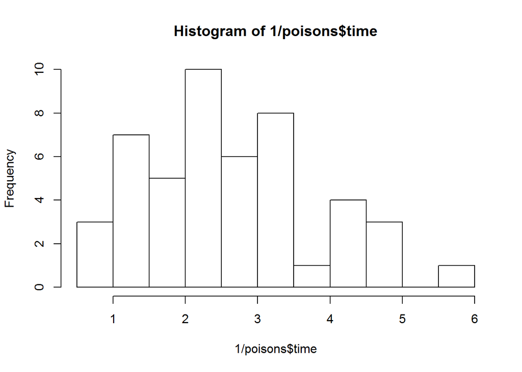

```r
hist(1/poisons$time)
```

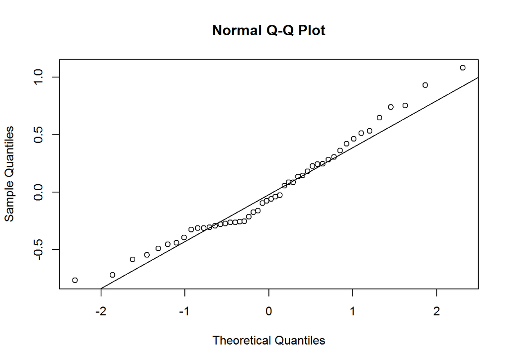

```r
qqnorm(mRats.recip$res)
qqline(mRats.recip$res)
```

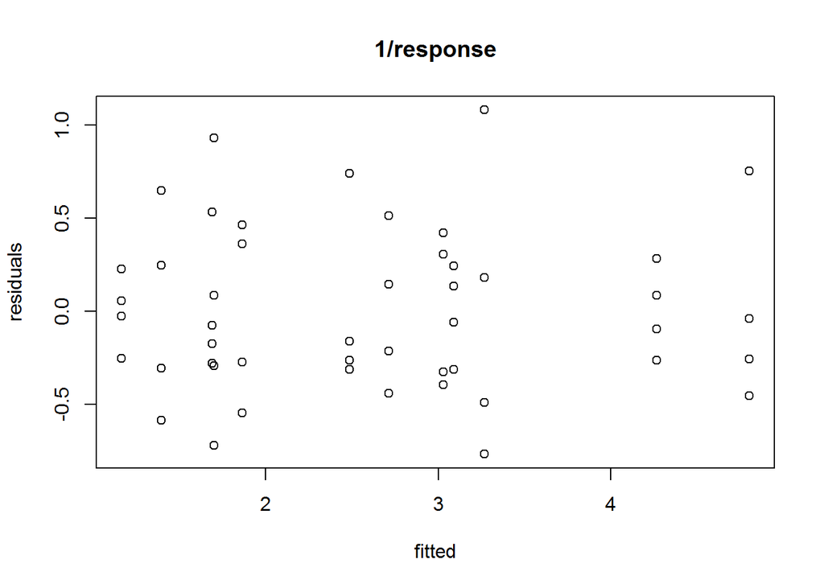

```r
plot(mRats.recip$fitted, mRats.recip$res, xlab="fitted", ylab="residuals",main="1/response")
```

Shape of the distribution did not change, but heteroskedasticity is gone.

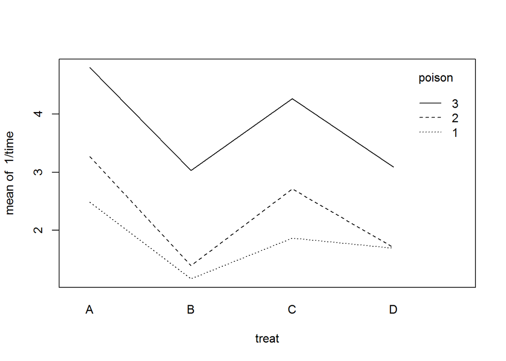

```r
with(poisons,interaction.plot(treat,poison,1/time))
```

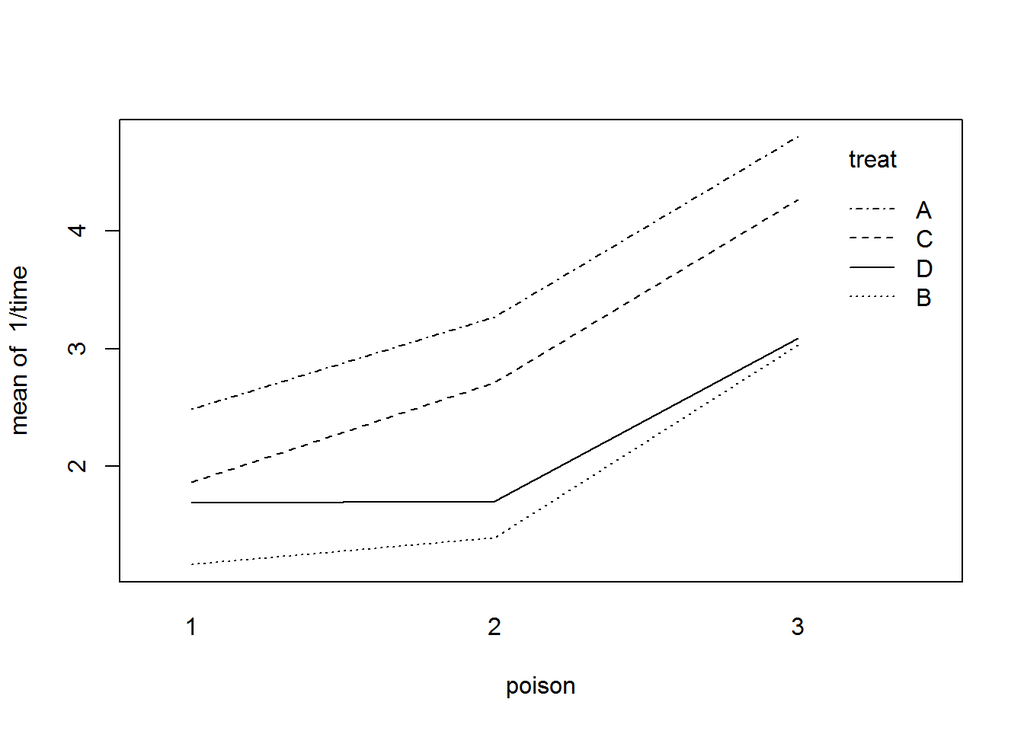

```r
with(poisons,interaction.plot(poison,treat,1/time))
```

```r
idx<-(mRats.recip$fitted.values<median(mRats.recip$fitted.values))
bptest(1/poisons$time~poisons$poison*poisons$treat)
```

```
##
##  studentized Breusch-Pagan test
##
## data:  1/poisons$time ~ poisons$poison * poisons$treat
## BP = 15.551, df = 11, p-value = 0.1586
```

```r
fligner.test(mRats.recip$residuals,idx)
```

```
##
##  Fligner-Killeen test of homogeneity of variances
##
## data:  mRats.recip$residuals and idx
## Fligner-Killeen:med chi-squared = 0.010516, df = 1, p-value =
## 0.9183
```

Reciprocal transformation worked. Since interactions did not seem to be significant, here is the model assuming no interaction:

```r
mRats.main <- lm(1/time ~ poison + treat,data=poisons)
summary(mRats.main)
```

```
##
## Call:
## lm(formula = 1/time ~ poison + treat, data = poisons)
##
## Residuals:
##      Min       1Q   Median       3Q      Max
## -0.82757 -0.37619  0.02116  0.27568  1.18153
##
## Coefficients:
##             Estimate Std. Error t value Pr(>|t|)
## (Intercept)   2.6977     0.1744  15.473  < 2e-16 ***
## poison2       0.4686     0.1744   2.688  0.01026 *
## poison3       1.9964     0.1744  11.451 1.69e-14 ***
## treatB       -1.6574     0.2013  -8.233 2.66e-10 ***
## treatC       -0.5721     0.2013  -2.842  0.00689 **
## treatD       -1.3583     0.2013  -6.747 3.35e-08 ***
## ---
## Signif. codes:  0 '***' 0.001 '**' 0.01 '*' 0.05 '.' 0.1 ' ' 1
##
## Residual standard error: 0.4931 on 42 degrees of freedom
## Multiple R-squared:  0.8441, Adjusted R-squared:  0.8255
## F-statistic: 45.47 on 5 and 42 DF,  p-value: 6.974e-16
```

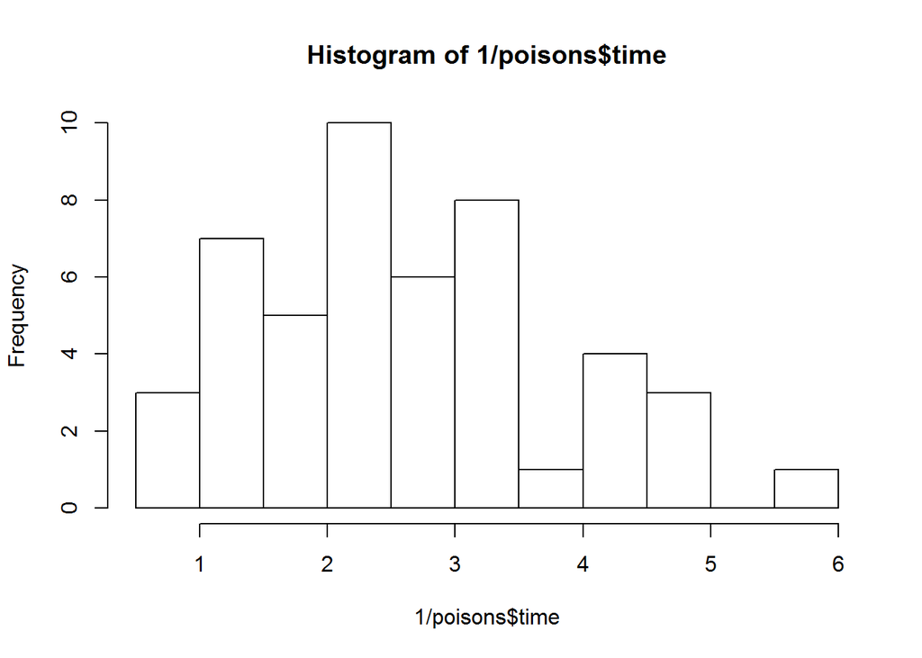

```r
hist(1/poisons$time)
```

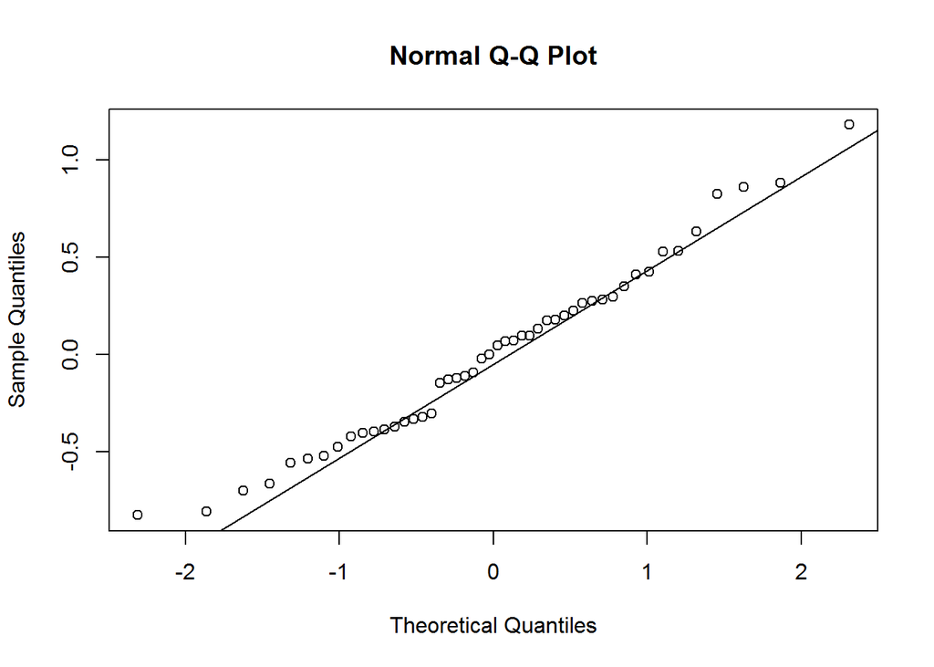

```r
qqnorm(mRats.main$res)
qqline(mRats.main$res)
```

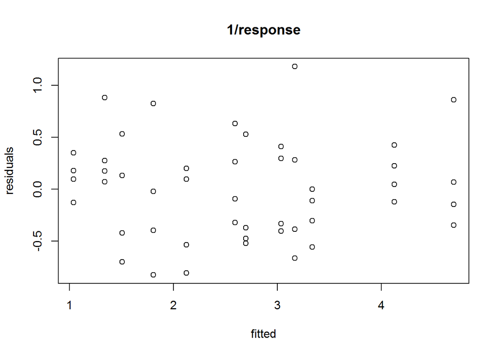

```r
plot(mRats.main$fitted, mRats.main$res, xlab="fitted", ylab="residuals",main="1/response")
```

```r
idx<-(mRats.main$fitted.values<median(mRats.main$fitted.values))
bptest(1/poisons$time~poisons$poison+poisons$treat)
```

```
##
##  studentized Breusch-Pagan test
##
## data:  1/poisons$time ~ poisons$poison + poisons$treat
## BP = 7.5079, df = 5, p-value = 0.1855
```

```r
fligner.test(mRats.main$residuals,idx)
```

```
##
##  Fligner-Killeen test of homogeneity of variances
##
## data:  mRats.main$residuals and idx
## Fligner-Killeen:med chi-squared = 0.034504, df = 1, p-value =
## 0.8526
```

Model with main effects only fits well too.

Fit inverse Gaussian model.

Possible links for inverse.gaussian family are: 1/mu^2, inverse, identity and log.

```r
mRats.ig<-glm(time~poison+treat,family=inverse.gaussian(link="inverse"),data=poisons)
summary(mRats.ig)
```

```
##
## Call:
## glm(formula = time ~ poison + treat, family = inverse.gaussian(link = "inverse"),
##     data = poisons)
##
## Deviance Residuals:
##      Min        1Q    Median        3Q       Max
## -0.67683  -0.24040  -0.06793   0.18631   0.66877
##
## Coefficients:
##             Estimate Std. Error t value Pr(>|t|)
## (Intercept)   2.6465     0.1939  13.648  < 2e-16 ***
## poison2       0.2900     0.1566   1.853    0.071 .
## poison3       1.9660     0.1929  10.192 6.34e-13 ***
## treatB       -1.6095     0.2110  -7.627 1.87e-09 ***
## treatC       -0.5835     0.2347  -2.486    0.017 *
## treatD       -1.2940     0.2187  -5.917 5.24e-07 ***
## ---
## Signif. codes:  0 '***' 0.001 '**' 0.01 '*' 0.05 '.' 0.1 ' ' 1
##
## (Dispersion parameter for inverse.gaussian family taken to be 0.1139811)
##
##     Null deviance: 25.7437  on 47  degrees of freedom
## Residual deviance:  4.5888  on 42  degrees of freedom
## AIC: -85.701
##
## Number of Fisher Scoring iterations: 2
```

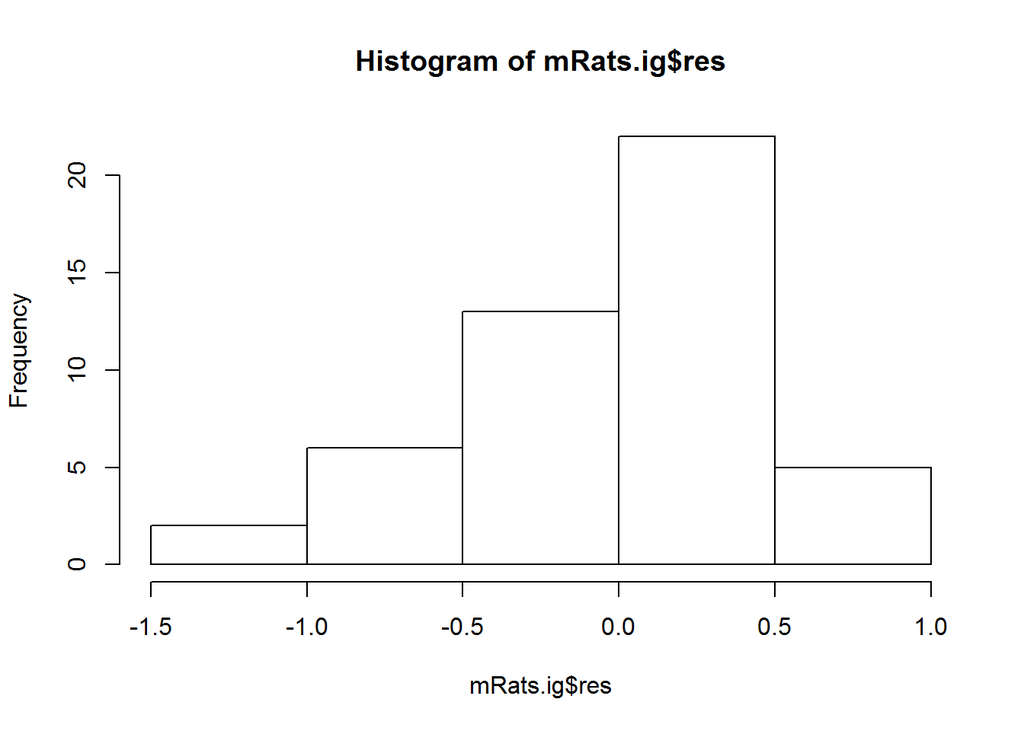

```r
hist(mRats.ig$res)
```

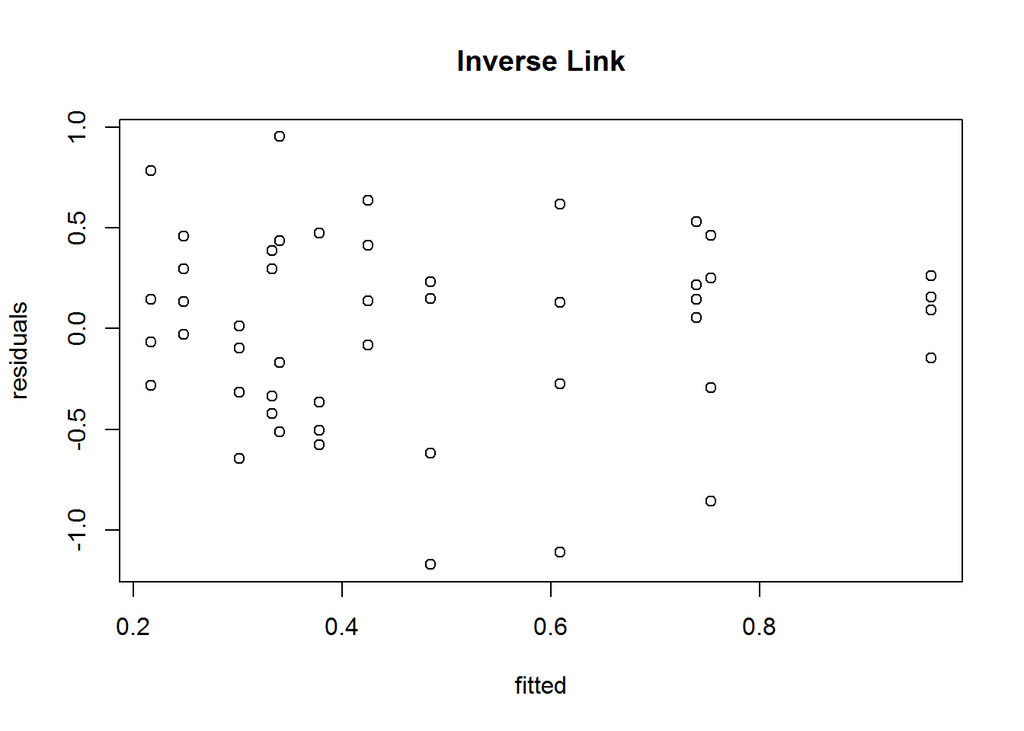

```r
plot(mRats.ig$fitted, mRats.ig$res, xlab="fitted", ylab="residuals",main="Inverse Link")
```

```r
idx<-(mRats.ig$fitted.values<median(mRats.ig$fitted.values))
fligner.test(mRats.ig$residuals,idx)
```

```
##
##  Fligner-Killeen test of homogeneity of variances
##
## data:  mRats.ig$residuals and idx
## Fligner-Killeen:med chi-squared = 0.43861, df = 1, p-value =
## 0.5078
```

Heteroskesticity is removed without a transformation.